# Logistic Regression

Review:

- In machine learning, we often have **regression** problems and **classification** problems. These often need different kinds of algorithms to solve.
- **Regression**: the answer you are trying to predict is a number. For example, our housing price prediction problem was a regression problem.
- **Classification**: the answer you are trying to predict is categorical. This includes problems where the answer is one of many categories, or a simple binary yes/no or true/false problem.
  - Examples of classification problems:
    - Classify an image as a dog or a cat.
    - Classify an email as spam or not-spam.
    - Classify a credit card or debit card transaction as fraudulent or not.
    - Classify a tumor as malignant or not.
  - All of these are **binary classification** problems.

## Classification

- In classification problems, we use the term **class** or **category** for the answer that we are predicting (that our model will eventually predict).
- We will focus on **binary classification** for the moment. We will denote our two classes as "1" and "0" (one and zero, positive and negative) which align nicely with questions that can be phrased as yes/no or true/false. For questions that don't (e.g., cat-vs-dog), we can arbitrarily pick one of them to be the "positive" class (1) and the other to be the "negative" class (0).
  - It is understood that the terms "positive" and "negative" don't have "good" and "bad" connotations --- everything we're going to learn would work the same way if we swapped the 0/1 classes around.
- Even though we are technically predicting a number (0 or 1), using a regression algorithm like linear regression really won't work here.

## Put all of this on the board

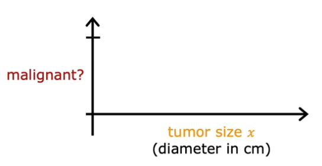

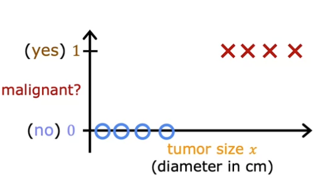

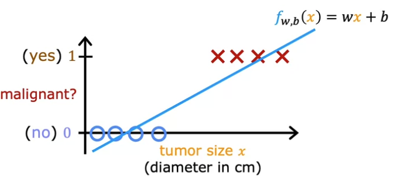

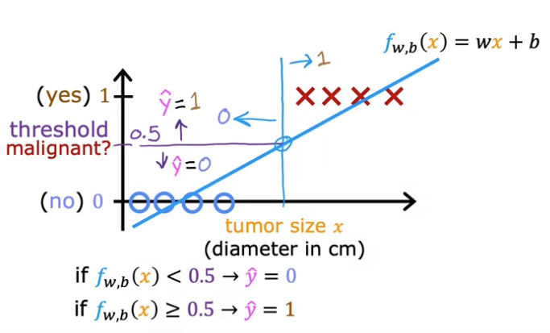

This really isn't appropriate, even with this threshold, because linear regression will also predict numbers less than zero and greater than 1.

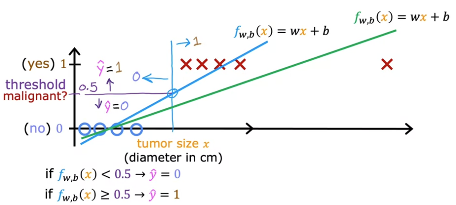

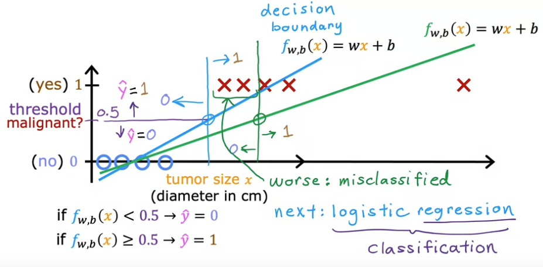

## Logistic regression

- Instead, we need a dedicated **classification** algorithm. The one we will study first is, oddly named, **logistic regression**, yet this is not a regression algorithm.
- The name comes from the fact that logistic regression fits a **logistic** (S-shaped) curve to a data set, in the same way that linear regression fits a line to a data set.

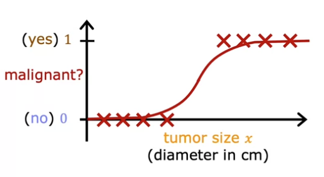

## on board

Draw curve on board.

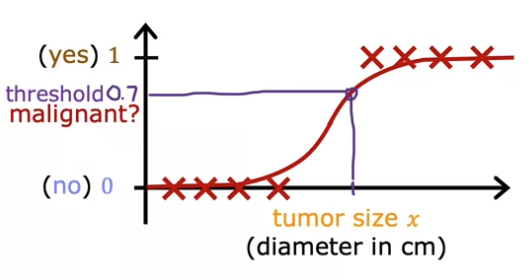

## Math

- We first have to define the mathematical function that creates this S-shaped curve, the **sigmoid** function, or sometimes called the **logistic** function.
- We usually write this function like this:

$$\sigma(x) = \frac{1}{1+e^{-x}} = \frac{e^x}{e^x+1} = 1 - \sigma(-x)$$

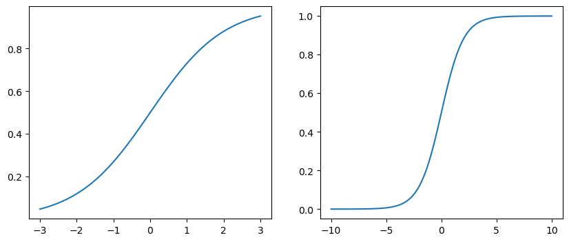

```python
import numpy as np
import matplotlib.pyplot as plt

def sigmoid(x):
    return 1/(1 + np.exp(-x))

x_plot1 = np.linspace(-3, 3, 100)
x_plot2 = np.linspace(-10, 10, 100)
y_plot1 = sigmoid(x_plot1)
y_plot2 = sigmoid(x_plot2)

fig, (ax1, ax2) = plt.subplots(1, 2, figsize=(10, 4))
ax1.plot(x_plot1, y_plot1)
ax2.plot(x_plot2, y_plot2)
plt.show()
```

## Logistic regression model

- Recall that in linear regression, we used the model

$$f_{w, b}(x) = wx + b$$

or when we rewrote this using the dot product and combined the $b$ term into the $w$ vector,

$$f_{w}(x) = w\cdot x \qquad \text{(this is now the dot product)}$$

- What we will do in logistic regression is take our linear regression model and pass it through the sigmoid function:
  - Define $z = w\cdot x$,
  - and $g(z) = \dfrac{1}{1+e^{-z}}$
  - And so our complete model for logistic regression is:

  $$f_{w}(x) = g(w \cdot x) = \dfrac{1}{1+e^{-w \cdot x}}$$

  Remember that $w$ and $x$ are vectors of length $n+1$, since we have $n$ features. We renamed $b$ as $w_0$, and we will always have $x_0$ set to 1 in our data, which when we take the dot product $w \cdot x$, always multiplies $w_0$ by 1.
- Remember what this function $f$ does: it takes a vector of features $x$ and outputs a number between 0 and 1.

## Interpreting the output of this model

- Think of the output of $f(x)$ as the probability that the class is 1 (the positive class).
- So in our example where $x$ is the size of a tumor and $y$ is 0 for a non-malignant tumor and 1 for a malignant tumor, we can interpret $\hat{y} = f(x)$ as the probability that a tumor of size $x$ is malignant.
- Quick probability notation:
  - We use $P(\text{something})$ to denote the probability of something happening.
- You will sometimes see the notation $f(x) = P(y=1 \mid x;w)$ for logistic regression; this means that we interpret $f(x)$ as the probability that $y$ (the correct output for input $x$) as being equal to 1, given the input features $x$ and parameters $w$.

## The decision boundary

- Remember our model $f(x)$ outputs a number between 0 and 1, but we really want the model to only predict **exactly** 0 or 1.
- The most common thing to do here is that when $f(x) \geq 0.5$, we predict 1, and when $f(x) < 0.5$, we predict 0.
- Mathematically, here's what this means:

$$\begin{align*} f(x) & \geq 0.5 \\ g(z) & \geq 0.5 \\ z & \geq 0 & & \qquad \text{ look at the graph} \\ w \cdot x & \geq 0 \end{align*}$$

In other words, our model predicts 1 whenever $w \cdot x \geq 0$, and conversely, predicts 0 whenever $w \cdot x < 0$.

### Visualization

Consider a situation with two input features $x_1$ and $x_2$. Suppose our data looks likes this, with the x's denoting the positive class and the o's denoting the negative class:

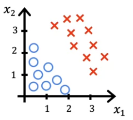

We know

$$f(x) = g(z) = g(w\cdot x) = g(w_0 x_0 + w_1 x_1 + w_2 x_2)$$

As an example, suppose $w_0 = -3$, $w_1 = 1$, and $w_2=1$. Also, remember $x_0$ is always 1 (it's a "fake" feature), so we will be able to use this to simplify.

Let's look at how logistic regression makes predictions. In particular, we'd like to visualize where $z=w\cdot x \geq 0$ and where $z=w \cdot x < 0$. To do this, it's easiest to examine a line called the **decision boundary**, which is where $z=w\cdot x=0$.

$$\begin{align*} z &= w\cdot x \\ z &= w_0 x_0 + w_1 x_1 + w_2 x_2 \\ z &= -3 + x_1 + x_2 = 0 \\ &\quad x_1 + x_2 = 3 \end{align*}$$

If you plot this line on the graph, you will see it divides the two classes perfectly.

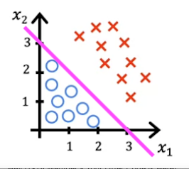

### Non-linear decision boundaries

- We can also do this for data that requires a curve of some sort to separate the two classes:

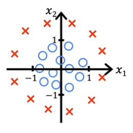

- Here, we would need a circular decision boundary. Just like adding in quadratic (or higher order polynomial) features to linear regression can help us fit non-linear data sets, the same principles apply here.
- Suppose we use the features $x_1^2$ and $x_2^2$ rather than just $x_1$ and $x_2$ (or you can imagine we use $x_1$ and $x_2$ but set their weights to zero):

  $z = w\cdot x$

  $z = w_0 x_0 + w_1 x_1^2 + w_2x_2^2$

$$\begin{align*} z &= w\cdot x \\ z &= w_0 x_0 + w_1 x_1^2 + w_2x_2^2 \\ \end{align*}$$

And suppose we set $w_0 = -1$, $w_1=1$, and $w_2=1$:

$$\begin{align*} z &= w_0 x_0 + w_1 x_1^2 + w_2x_2^2 \\ z &= -1 + x_1^2 + x_2^2=0 \\ &\quad x_1^2 + x_2^2 = 1 \end{align*}$$

This decision boundary will look something like this:

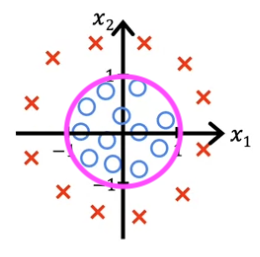

## comments

In general, you can get any kind of conic section with the squares of the parameters plus x_1 times x_2.

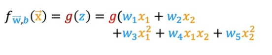

If you start adding higher order polynomials, you can get arbirariliy complicated decision boundaries.

- It's worth mentioning that if you don't use any higher-order features, then logistic regression's decision boundary will always be a straight line (similar how in linear regression, without higher order features, the model will always be a straight line).